# GEOG-503 Lab 7

## Due date:

Oct 17 (Wednesday) 11:59 pm

## What to submit:

The Jupyter Notebook that contains solutions to the following questions. File name convention for submission: **lastname_firstname_lab7.ipynb**

It must be submitted to [myCourses](https://mycourses.binghamton.edu/)

## Questions

Answer the questions or complete the tasks outlined in bold below, use the specific method described if applicable.

## Data

- http://spatial.binghamton.edu/geog503/data/lab7_data.zip

# Question 1

Write a script that creates a new polygon feature class containing a single (square) polygon with the following coordinates: (0, 0), (0, 1,000), (1,000, 1,000), and (1,000, 0). (5 pt.)

```python
try:
    import archook #The module which locates arcgis
    archook.get_arcpy()
    import arcpy
except ImportError:
    print("import arcpy error")
```

```python
import os
import geopandas as gpd
arcpy.env.workspace = os.getcwd() + '/data'
arcpy.env.overwriteOutput = True
point_lst = [[0,0],[0,1000],[1000,1000],[1000,0]]
polygon_arry = arcpy.Array()
for coordinate in point_lst:
    polygon_arry.add(arcpy.Point(coordinate[0],coordinate[1]))
print polygon_arry.count
```

```
4
```

```python
spatialRef = arcpy.SpatialReference(4326)
fc = arcpy.Polygon(polygon_arry,spatialRef)
arcpy.CopyFeatures_management(fc,"Results/Q1_polygon.shp")
```

```
<Result 'H:\\G560\\Lab7/data\\Results\\Q1_polygon.shp'>
```

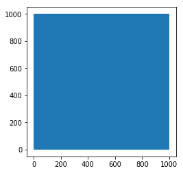

```python
shp_fl = gpd.read_file("./data/Results/Q1_polygon.shp")
%matplotlib inline
shp_fl.plot()
```

# Question 2

Write a script that determines the perimeter (in meters) and area (in square meters) of each of the individual islands of the **Hawaii.shp** feature class. Note that this is a multipart feature class. (5 pt.)

```python
fc = 'Hawaii.shp'
cursor = arcpy.da.SearchCursor(fc,["SHAPE@"])
for row in cursor:
    polygon_token =  row[0]
    print 'partCount = ' + str(polygon_token.partCount)
    for index,part in enumerate(polygon_token):
        polygon = arcpy.Polygon(part,spatialRef)
        line = arcpy.Polyline(part,spatialRef)
        print 'Part %-2s :  Length = %10.2f    Area = %15.2f' %(index,line.length,polygon.area)
```

```
partCount = 11
Part 0  :  Length =  498725.06    Area =  10486352988.49
Part 1  :  Length =   56881.00    Area =    119076863.76
Part 2  :  Length =   79591.07    Area =    364740852.50
Part 3  :  Length =  237012.26    Area =   1907482650.23
Part 4  :  Length =  161088.60    Area =    685386630.23
Part 5  :  Length =    4352.76    Area =      1031618.81
Part 6  :  Length =    4695.33    Area =      1256964.65
Part 7  :  Length =  272519.59    Area =   1577775022.82
Part 8  :  Length =   78651.62    Area =    196286564.36
Part 9  :  Length =    4013.22    Area =       856335.76
Part 10 :  Length =  172463.40    Area =   1449442867.86
```

# Question 3

Write a script that creates a minimum bounding rectangle for the **Hawaii.shp** feature class. There is a tool called [Minimum Bounding Geometry](https://goo.gl/PdRWUP) that can do this. However, your script should NOT use the tool arcpy.MinimumBoundingGeometry_management. Instead, use the [hullRectange](https://goo.gl/QJxpmp) properties of a Geometry object to create the minimum bounding rectange (10 pt.)

```python
arcpy.env.overwriteOutput = True
fc = 'Hawaii.shp'
output = arcpy.env.workspace + '//Results//Q3_envelope.shp'
arcpy.MinimumBoundingGeometry_management(fc,output)
cursor = arcpy.da.SearchCursor(output,["SHAPE@"])
print 'Coordinates of the minimum bounding rectangle:'
for row in cursor:
    for muti_polygon in row:
        for polygon in muti_polygon:
            for point in polygon:
                print 'X = %12.5f,   Y = %12.5f' %(point.X,point.Y)
del row,cursor
```

```
Coordinates of the minimum bounding rectangle:
X = 453956.56852,   Y = 2540498.57596
X = 966495.57971,   Y = 2200072.27127
X = 881991.45582,   Y = 2072844.55852
X = 369452.44462,   Y = 2413270.86321
X = 453956.56852,   Y = 2540498.57596
```

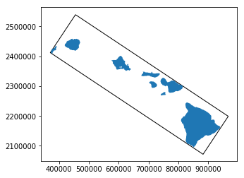

```python
shp_fl = gpd.read_file("./data/Results/Q3_envelope.shp")
shp_fc = gpd.read_file("./data/Hawaii.shp")
%matplotlib inline
base =shp_fl.plot(color='white', edgecolor='black')
shp_fc.plot(ax=base)
```

# Question 4

Write a script that creates a Polygon shapefile based on the coordinates from **coordinates.txt**, which contains coordinate pairs (X, Y) for 11 polygons. You should use relevant Geometry classes to perform this task. Do NOT use InsertCursor function. Use the spatial reference of Hawaii.shp for the resulting Polygon shapefile. (20 pt.)

```python
fc = 'Hawaii.shp'
spatialRef = arcpy.Describe(fc).spatialReference
pnt = arcpy.Point()
array = arcpy.Array()
array1 = arcpy.Array()
with open ('./data/coordinates.txt') as f:
    line =  f.readline()
    while line:
        if "Feature "in str(line):
            array1.add(array)
            array = arcpy.Array()
        else:
            pnt = arcpy.Point(str(line).split(",")[0].split("=")[1],str(line).split(",")[1].split("=")[1])
            array.add(pnt)
        line =  f.readline()
array1.add(array)
```

```python
fc = arcpy.Polygon(array1,spatialRef)
arcpy.env.workspace = os.getcwd() + '/data/Results'
arcpy.CopyFeatures_management(fc,"Q4shapefile.shp")
```

```
<Result 'H:\\G560\\Lab7/data/Results\\Q4shapefile.shp'>
```

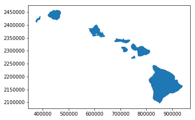

```python
shp_fl = gpd.read_file("./data/Results/Q4shapefile.shp")
%matplotlib inline
shp_fl.plot()
```